# Correlates of conflict resolution across cultures

Zach Garfield

9/28/2020

## Abstract

Conflicts are ubiquitous between individuals within communities and organizations as well as between groups, including societies and nations. Effective conflict resolution processes are an essential component of individual well-being, group functioning, and global security. Leadership is often a key component of conflict management and resolution. The evolutionary human sciences have suggested conflict resolution processes are shaped by psychological heuristics, social norms, and cultural variability. Despite much theorizing there is limited empirical data on conflict resolution processes across the full range of human cultural diversity. The current study uses a new cross-cultural database of 109 researcher-coded leadership dimensions from over 1200 ethnographic texts describing 59 cultures, developed from the electronic Human Relations Area Files – a digital collection of primary ethnographic documents. These results provide a rare view of the correlates of conflict resolution processes and reveal their universality across cultures and diversity across social contexts.

## Introduction

Humans and human societies are exceptional in our abilities to sustain large-scale, complex cooperation (Henrich and Henrich 2007; Santos and West 2018), including between relatives, strangers, residential communities, and political groups. Nature, including human sociality, is clearly not “red in tooth and claw” as Tennyson (1850) famously composed. Diverse non-human species also demonstrate and depend on substantial cooperation (e.g., Allee 1951). Such cooperative relationships, however, are vulnerable and can quickly decay in the face of escalating and unresolved conflicts, particularly between autonomous human populations, such as extended kin groups and nation states. Group living necessarily creates ample opportunity for inter-individual conflict. Across mammalian species the killing of conspecifics is most frequent among social species that rely on and engage in territorial defense, and among primates especially (Gómez et al. 2016). Various dispute settlement mechanisms are equally widespread across social species and conflict resolution processes are expected to be an essential and universal feature of human groups (Brown 1991; Garfield, Syme, and Hagen 2020; Boehm 1982). The underlying correlates of individuals who function to resolve conflicts within and between groups and the specific cultural and group contexts that present greater conflict resolution demands have been widely discussed across scientific disciplines, but empirical evidence from a representative sample of human social and cultural diversity has remained unavailable. Through novel exploratory comparative analyses the present study aims to fill these empirical gaps.

### Sociality and demands of conflict resolution

For a minority of mammals including humans and most primates, group living is obligatory (Hrdy 2006). Group living then must have in some contexts among some species, offered individuals a net fitness benefit over evolutionary history (Alexander 1974). Putative benefits include reduced individual risks from herd formation, coordination of individuals to accomplish highly profitable yet difficult goals, and increased abilities to monitor and patrol territory (Bickerton and Szathmáry 2011; Willems and van Schaik 2017; Smith et al. 2012). In the context of group living, co-residents who effectively solve inter-individual conflicts can benefit both at the individual-level via reduced aggression (direct and indirect) and increased cooperation (Alexander 1974; Chapman and Valenta 2015; Hess and Hagen 2006). Groups also stand to benefit from established conflict resolution mechanisms via cultural group selection processes (Richerson et al. 2016; Smith 2020) and gains from international cooperation (Snidal 1991; Uitto and Duda 2002).

The evolution and maintenance of group living faces significant challenges stemming from, in part, opportunities for conflicts within and between groups – a point further exemplified given that most species, including about 70% of all mammals, do not live in groups (Wilson and Reeder 2005). Self-interested individuals in close proximity can be in conflict, for example, over access to material resources, mating opportunities, and preferential territory (Morris, Bastock, and Moynihan 1954; Parker 2006; Smith 1985; Ross 1983). Long-term co-residents and close kin can develop additional conflicts within a social or organizational structure including over position in a status hierarchy or social network and in economic and reciprocal exchange (Parker, Royle, and Hartley 2002; Boulding 1957; Hames 2015; Berger, Rosenholtz, and Zelditch 1980). Moreover, groups of individuals across all levels of social organization (e.g., kin, residential, economic, or political levels) can develop various inter-group conflicts (Wrangham and Glowacki 2012; Roscoe 2009; Glowacki, Wilson, and Wrangham 2017).

Although conflicts are common, conflict resolution mechanisms are also common and typically associated with a leadership role. Social nonhuman species demonstrate conflict resolution mechanisms such as reconciliation behaviors between individuals following an aggressive conflict as well as intervening behaviors by a third-party, often a high-ranking or influential group member (Aureli, Cords, and van Schaik 2002; Wilson 1980; Aureli, Waal, and Waal 2000). Among human groups, collectivist philosophies, i.e., “united we stand, divided we fall,” are a common feature of national identity and political philosophies espoused by leaders to their constituents (Jacobs, Aesop, and Hejduk 1991) and can promote prosocial, anti-conflict norms. Theoretical models also suggest cooperative dynamics can emerge in heterogeneous, conflict-prone groups when, for example, dominant leaders provide policing and conflict resolution services (Frank 1996; Mesterton-Gibbons et al. 2011).

### Conflict resolution in comparative perspective

Smith et al. (2016) provide an empirical cross-species and cross-cultural comparison of within-group conflict resolution, contrasting nonhuman animal populations with small-scale human populations. Across their sample, within-group conflict resolution functions were generally not widely distributed, i.e., a small number of adults had greater influence in conflict resolution in both nonhuman and small-scale human societies. This strongly implicates the role of individual leaders, or individuals who maintain a disproportionate level of influence within a group (von Rueden and van Vugt 2015; Kantner 2010), in the resolution of within-group conflicts.

Smith et al. (2016) also found that among both nonhuman species and small-scale human societies leaders and followers generally equally benefit from within-group conflict resolution (though the specifics of ‘relative benefits’ were not coded for) and conflict resolution roles are more often achieved rather than ascribed, suggesting followers and group dynamics shape the qualities of leaders who resolve conflicts. In small-scale human societies, however, leaders who resolve within-group conflicts are more likely to have to coercive power (Smith et al. 2016). Although the Smith et al. (2016) sample is small (*n* = 16) and their empirical measures are ratings based on ethnographic and ethological expertise, these results do provide a novel and useful framework for developing a broader view of conflict resolution among humans and in evolutionary perspective.

Among human populations, and smaller-scale societies in particular, social norms, cultural institutions, and supernatural beliefs can prevent and mediate potential or actual instances of inter-individual conflict without direct resolution efforts of a third party (Glowacki 2020; Basedow 1925). For example, the ekila and poison oracle practices among Central African foragers (Lewis 2008) and other supernatural mediation and divination rituals can function to resolve conflicts without much decision-making autonomy or influence from a third-party community member. Nonetheless, concerted dispute settlement by a third party is probably universal among human groups in at least some contexts (Brown 1991; Garfield, Syme, and Hagen 2020). Given the broad phylogenetic distribution of conflict resolution behaviors and the universality of conflict resolution processes among human populations, there are likely to be evolved psychological underpinnings to human conflict resolution strategies, as well as reliable facultative responses to ecological conditions and culturally evolved systems exhibiting variability and convergence.

### Culture and conflict resolution

Early ethnographers extensively documented cultural variation in typologies of conflicts such as feuds, warfare, and fighting, but cohesive theories grappling with cultural variation were developed much later including theories on the the evolution of human warfare (Turney-High 1949; Wright 1942) and influential sociological theories (e.g., Durkheim, Marx, Weber) (for review see Levine 1961; Sluka 1992). Early anthropologists also tended to focus heavily on the nature and structure of conflicts, much more so than conflict resolution. For example, British sociocultural and interpretive anthropologists, e.g. Gluckman (1956) and Turner (1970), suggested conflicts within larger social units reinforce and contribute to the cohesiveness of larger social structures. Structural anthropologists, however, (e.g., Beals and Siegel 1966) suggested conflict is a deleterious consequence of various “pressures” exerted on social systems, and often contrasted intrafamilial, intracommunity, intercommunity, and intercultural conflicts.

More recently, evolutionary anthropologists have emphasized the important role of leaders, senior kin, and other influential community members as the managers of conflicts withing and between families and kin groups and have suggested such conflict resolution processes underlay much of human psychological, biological, and cultural evolution (Glowacki and von Rueden 2015; Hames 2015; Garfield, von Rueden, and Hagen 2019; Boehm 2013). Drawing on the ethnography of smaller-scale, politically autonomous populations and empirical field data Glowacki and von Rueden (2015) frame within-group conflict resolution as one type of collective action problem populations must overcome. They suggest effective leadership emerges and is selected for as a critical component in the resolution of collective action problems within an institutional system and individuals with wider social networks, greater knowledge, and physical fromidability will be more likely to effectively resolve inter-individual conflicts. Nonetheless, most of the evolutionary anthropological literature on conflict has focused on evolutionary underpinnings of warfare and between group conflict (see Glowacki, Wilson, and Wrangham 2017; Sluka 1992; Lopez 2020).

## Study aims

Conflict resolution occurs among every human society but we currently know very little about whether such processes utilize similar or variable social mechanisms and if they rely on the same individual characteristics across the diversity of human social and cultural contexts. Answering such questions requires a broad, comparative, and cross-cultural framework. Based on the current theoretical and empirical literature, outstanding questions on human conflict resolution include: 1) what are the underlying behavioral, personality, or other characteristics that characterize leaders who resolve conflicts across diverse cultural and social contexts?; 2) what are the specific costs or benefits individuals incur from conflict resolution processes?; and 3) how widespread is coercive authority or prosociality of leaders who solve disputes, across diverse societies? Lastly, 4) does group context or cultural typologies predict variation in human conflict resolution? The present study aims to fill these empirical gaps in the human conflict resolution literature through a detailed exploratory analysis of a new cross-cultural database constructed from the ethnographic record (produced by Garfield, Syme, and Hagen (2020)).

Whereas Garfield, Syme, and Hagen (2020) provide a broad exploratory analyses on the universality and variability of leadership dimensions using the “leadership data package,” the current study focuses in detail on the “conflict resolution” variable in this database to descriptively analyze the presence of ethnographic evidence for conflict resolution processes across subsistence types (e.g., hunter-gatherers, pastoralists, or agriculturalits), and group context (e.g., residential, kin, or political groups), and to identify if this evidence is biased towards conflicts within or between groups. Text-analysis is used to provide insight into the linguistic content of the ethnographic record and the words ethnographers frequently use to describe conflict resolution. The leadership dimensions predictive of evidence for conflict resolution will identity the behavioral and phenotypic correlates of individuals who resolve conflicts and of the cultural views of conflict resolution across human societies. Lastly, culture and group-level measures will be used to predict evidence for conflict resolution to identify how conflict resolution may covary with cultural and social contexts.

## Methods

### Cross-cultural database

This study uses data from the *leadership data package* (DOI:10.5281/zenodo.4018788), a novel cross-cultural database originally constructed by Garfield, von Rueden, and Hagen (2019) and expanded by Garfield, Syme, and Hagen (2020), designed to capture a wide range of ethnographic content related to leadership from the 60-cultural Probability Sample Files (Naroll 1967) of the electronic Human Relations Area Files (eHRAF). The eHRAF is an electronic text database of primary ethnographic documents which can be queried using a thorough subject code system (Outline of Cultural Materials or OCM codes) and/or by keyword, at the paragraph level. The *leadership data package* is based on 1,212 ethnographic paragraphs (termed text records) extracted from the eHRAF using a broad search strategy targeting general descriptions of leadership. It includes two data frames of researcher-coded measures, one of which includes variables on evidence for 109 dimensions of leader qualities and functions, including conflict resolution (their *Resolve conflict* variable), as well as measures of costs and benefits for leaders and followers. A researcher-coded measure of group context (see Table 1), the context of leader functions (i.e., within-group, between-group, or both), and culture and document-level metadata (e.g., subsistence strategy, year of publication, author) are also provided. The current study uses this database of 1,212 text records, the associated 109 leadership dimensions, and culture and document-level measures in novel exploratory, comparative analyses on conflict resolution. For additional details on the construction of the database see Garfield, von Rueden, and Hagen (2019) and Garfield, Syme, and Hagen (2020).

### Data analysis

The first goal of the current study was to empirically describe the ethnographic record of human conflict resolution through text analyses. Ethnography-based data are fundamentally rooted in bodies of text authored by ethnographers and other professional writers. The semantic content of these documents can be analyzed using text analytic methods to supplement analyses from researcher-coded variables. A document-term matrix was developed of the corpus of text records and elasticnet logistic regression from the glmnet package (Friedman, Hastie, and Tibshirani 2010) was used to identify the terms that predict evidence for conflict resolution (see Results for additional details). Elasticnet regression models are penalized regression models that are effective when the number of predictors is large relative to the number of observations ($n<<p$). Elasticnet regression models in the current study used the “lasso” penalty ($\alpha=1$), which will often set many coefficients to 0, thereby identifying the most important predictors among all covariates.

Building on results from Garfield, Syme, and Hagen (2020), the second goal was to describe the distribution of evidence for conflict resolution across cultures with distinct subsistence strategies and across distinct group contexts. That is, when there is evidence leaders resolve conflicts, is it biased to a particular cultural or social context? And, to identify how evidence for conflict resolution in within or between group contexts varied compared across these categories. The third goal was to identify which leadership dimensions predicted evidence for conflict resolution. Two elasticnet logistic regression models were used to identify A) the qualities and functions of leaders who resolve conflicts and B) the cost and benefits for leaders and followers associated with conflict resolution processes. The fourth goal, also expanding on findings from Garfield, Syme, and Hagen (2020), was to more closely examine variation in conflict resolution by cultural and social variation, namely by subsistence strategy (see Figure 1) and group context (see Table 1), using logistic mixed effects models and the lme4 package (Bates et al. 2015).

All analyses were conducted with R version 4.0.2 (2020-06-22).

## Results

The *leadership data package* sample comprises 1212 text records from 321 documents describing 59 cultures. Detailed descriptive results of ethnographic paragraphs in the sample are given in Garfield, Syme, and Hagen (2020), including discussing of potential bias by ethnographer gender, year of publication, total pages of ethnography per culture, etc. (overall, potential biases along these lines were deemed to be negligible). The geographic distribution of the culture sample is reproduced here in Figure 1.

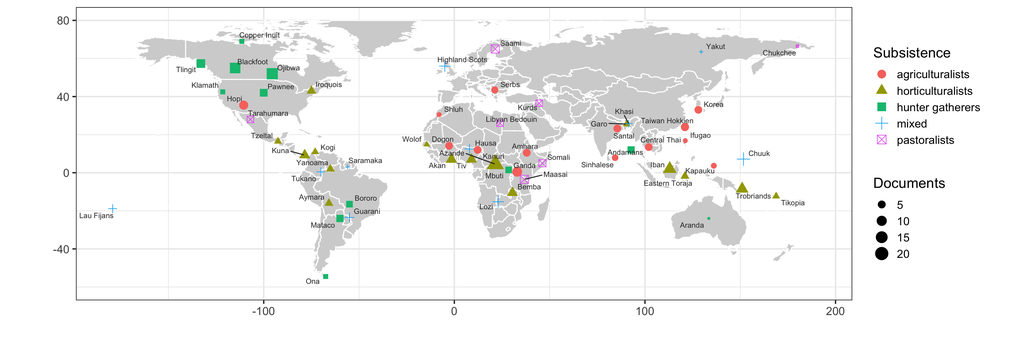

Figure 1: The geographical distributions of cultures in this analysis. Symbol shapes indicate subsistence strategy and symbol size indicates the number of documents available for that culture. Axes are degrees latitude and longitude. Reproduced from Garfield et al. (2020).

### Text analysis of conflict resolution ethnography

To empirically characterize the ethnographic record of conflict resolution, a document-term matrix (DTM) was created of all “informative” words in the corpus of text records and the frequency with which they occurred in each text record. In this matrix each row corresponds to one of the 1,212 text record and each column to one of the unique “informative” words, with the cell values indicating the number of times that word appears in that text record. Then, an elasticnet logistic regression model (with the lasso penalty, $\alpha = 1$) of *Resolve conflict* (0/1) was fit as a function of the frequencies of all 9656 words. Words that were strong positive predictors exemplify the semantic content and ethnographer diction of the text records which provided evidence for conflict resolution processes by leaders. The strongest positive predictors (terms) included, unsurprisingly, “dispute” and “quarrel,” describing conflict scenarios. The next group of positive predictors included, “peace,” “settle,” and “mediator,” describing resolution processes. Other notable positive predictors included, “decide,” implicating decision making processes by leaders and a few terms specific to social contexts, such as “religious” and “political” which suggests social context maybe critical in descriptions of conflict resolution. Several positive predictors were also specific to local and family contexts, such as “local,” “house,” and “clan.” Terms associated with more institutionalized and hierarchical leadership systems tended to be negative predictors. For example, “royal,” “son,” and “king” were negative predictors, suggesting the ethnographic record of leadership among kingdoms and by kings is less likely to discuss conflict resolution.

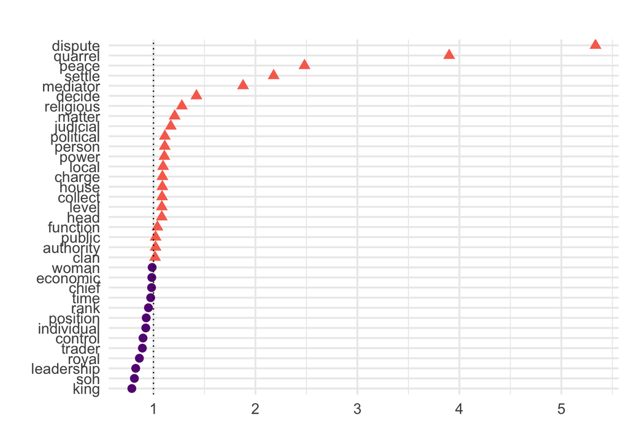

Figure 2: Non-zero coefficients of logistic elasticnet text analysis regression model of evidence for *Resolve conflict*. Coefficients indicate the words whose frequencies in each text record best predicted evidence for *Resolve conflict* in each text record. Red triangles indicate positive coefficents. Purple circles indicate negative coefficents.

### Evidence for conflict resoultion by subsistence and group context

The distribution of *evidence for* conflict resolution across subsistence strategies and group context (see Table 1) and in relationship to the context of conflict (e.g., within-group, between-group) is depicted in Figures 3 and 4, for the 152 text records which provide evidence for conflict resolution. The *Context of conflict* variable indicates if the evidence for the conflict resolution function was defined as “within-group”, “between-group”, “both”, or “unknown” (“unknown” category was only coded for three text records in total and has been removed from these figures).

Table 1: Operationalization of the group context variable. Reproduced from Garfield et al. (2020).

| Group context | Description |
| --- | --- |
| Residential subgroup | Informal groups of co-residents, social groups, age-based groups, or performance groups |
| Kin group | Groups based on kin relationships, such as lineages, phratries, and clans |
| Economic group | Subsistence groups, market groups, and other groups with primarily economic goals |
| Military group | All groups related to inter-group conflict |
| Religious group | Groups formed for spiritual or supernatural purpose |
| Political group (community) | Political groups at the level of the community, i.e., political leaders, such as village headmen, can potentially interact directly with most community members |
| Political group (supracommunity) | Political groups that encompass multiple residential communities, such as complex chiefdoms, regional political leaders, and kings or state-level leaders |

Figure 3 reveals that across cultures with distinct subsistence strategies, the ethnography of conflict resolution does not substantially vary across between or within-group conflicts and there is a substantial bias in favor of within-group conflict resolution processes, with one possible exception that pastoralists demonstrated slightly more relative evidence for between-group conflict resolution than other subsistence groups. Across all subsistence strategy types, however, there is evidence of between-group conflict resolution processes.

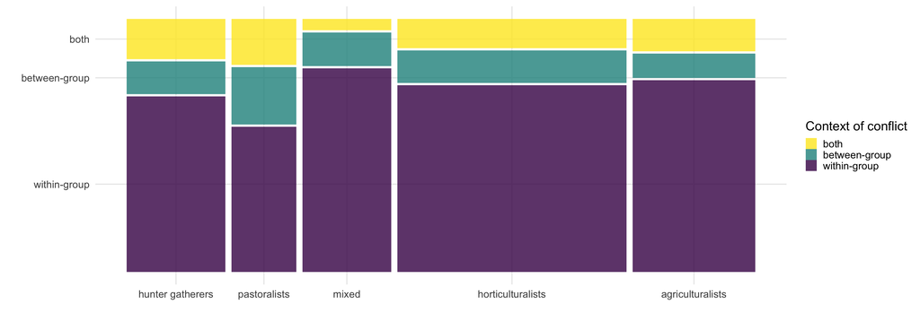

Figure 3: The distribution of text records providing evidence for conflict resolution by subsistence and the context of conflict. Areas of the bars are proportional to the number of text records in that category.

Across group contexts there are also general similarities in the distribution of within and between-group conflict resolution (see Figure 4), with two striking and obvious exceptions; leaders of religious groups primarily resolve within-group conflicts (with marginal evidence of conflicts involving both within and between group dimensions) and leaders of military groups are involved in a substantial amount of between-group conflict resolution, though there is evidence of within-group conflict resolution among military leaders as well.

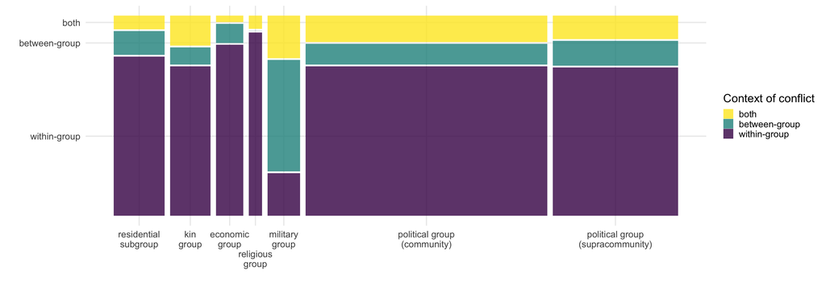

Figure 4: The distribution of text records providing evidence for conflict resolution by group context and the context of conflict. Areas of the bars are proportional to the number of text records in that category.

### Leadership dimensions predictive of conflict resolution

Two elasticnet logistic regression models (with the lasso penalty, $\alpha = 1$) of *Resolve conflict* were fit as a function of A) the other 72 quality and function leadership dimensions, and B) the 36 leadership costs and benefit measures (nine measures which include costs and benefits variables for both leaders and followers, i.e., $9\times2\times2$). See Tables S1 and S2 in the supplementary information for operational definitions of all leadership dimensions (reproduced from Garfield, Syme, and Hagen (2020)). These models aim to identify which dimensions were associated with evidence for conflict resolution. The qualities and functions were modeled separately from the costs and benefits.

The elastic net model using the 36 costs and benefit variables uses the $\lambda_{min}$ tuning parameter, which was chosen by cross-validation to minimize model deviance. The model of the 72 quality and function variables, however, uses $\lambda_{1SE}$, i.e., $\lambda$ value within 1 $SE$ of the optimized $\lambda_{min}$. Because there were many more predictors in the qualities and functions model the more conservative $\lambda_{1SE}$ results, with lower coefficients and fewer selected predictors was preferred; because the costs and benefits model included relatively fewer predictors, the optimized $\lambda_{min}$ model was preferred.

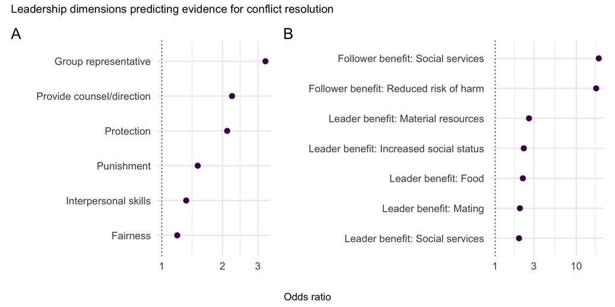

### Variation in social context of conflict resolution

Garfield, Syme, and Hagen (2020), in their systematic analyses of 109 leadership dimensions, identified *Resolve conflict* as a candidate universal of human leadership (see their Table 1), given this measure did not meaningfully vary by continental region, subsistence strategy, group context, or leader sex – four predictors applied to all leadership dimensions – relative to an intercept-only model. Here, the focus is on the *Resolve conflict* measure specifically and there is very little evidence for female leaders engaged in conflict resolution in the database. Therefore, to expand on the modeling approach by Garfield, Syme, and Hagen (2020), specifically for conflict resolution, a logistic mixed effects model of *Resolve conflict* was fit (similarly to the Garfield, Syme, and Hagen (2020) approach with random intercepts for document authors nested within cultures), but which excluded the *leader sex* term. This three-term model *did* show an improvement in fit over the intercept only model ($\Delta AIC = -2.33$).

Figure 6 plots the estimated marginal means of *continental region*, *subsistence strategy* and *group context* from the three-term logistic mixed effects model of *Resolve conflict* and Table 2 provides results of an ANOVA test of the fitted model. *Continental region* and *subsistence strategy* do not vary or predict *Resolve conflict*, however *group context* was a significant predictor ($\alpha = 0.05$).

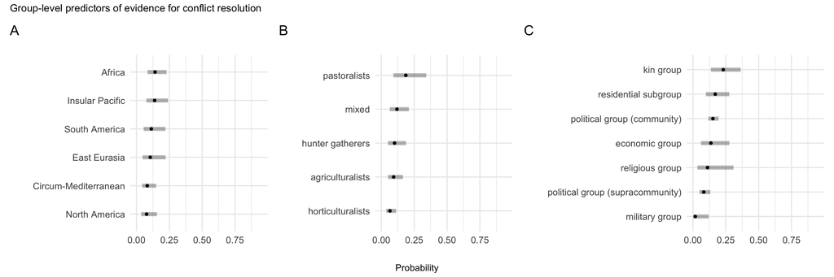

Figure 6: Estimated marginal means of evidence for conflict resolution by continental region (A), subsistence strategy (B), and group context (C) from a three-term logistic mixed effects regression model with random intercepts for author nested within culture. Values are on the response scale (probability).

Table 2: Analysis of deviance results (Type II Wald chisquare tests) of three-term model of Resolve Conflict.

|  | Chisq | Df | Pr(>Chisq) |
| --- | --- | --- | --- |
| group.structure2 | 14.652 | 6 | 0.023 |
| subsistence | 7.931 | 4 | 0.094 |
| region | 3.690 | 5 | 0.595 |

Pairwise comparisons of estimated marginal means from levels of *group context* were compared using contrast analysis to identify the varying contexts and those which predicted evidence for *Resolve conflict* in the three-term model. One pairwise comparison – *kin group* vs. *political group (supracommunity)* – produced a statistically significant mean difference (Tukey-adjusted p-value $< 0.05$) with *kin groups* producing the higher estimated marginal mean.

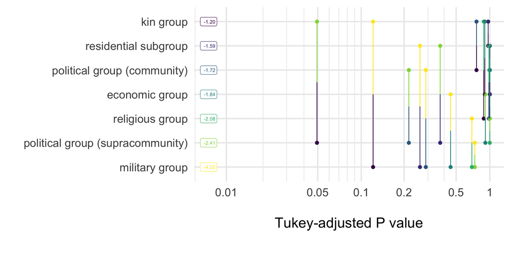

Figure 7: Plot of P values from pairwise comparisons of estimated marginal means of levels of *group context* from three-term logistic regression model or *Resolve conflict*

## Discussion

### Cross-cultural commonality and variability

The ethnographic record of leadership in conflict resolution provides substantially greater evidence for conflict resolution within-groups than between groups including across populations with variable subsistence strategies and across distinct social contexts (Figures 3 and 4). These results support recent work in anthropology emphasizing within-group heterogeneity, variability, and social complexity among populations such as mobile hunter-gatherers, often characterized as “small-scale” (e.g., Hill et al. 2011; Bird et al. 2019). Between-group conflicts, although relatively less represented in this ethnographic sample, are consistently documented across all subsistence types including, hunter-gatherers providing additional evidence for the ubiquity of inter-group conflicts across the vast majority of human societies and consistent with claims of the presence of inter-group conflict across human evolutionary history (Glowacki, Wilson, and Wrangham 2020; Hames 2019; Lopez 2016).

### The correlates of conflict resolution

Identifying the suite of traits commonly associated with conflict resolution capacities has received substantial focus and is of broad multidisciplinary, industrial, and political interest. The vast majority of studies on the behavioral and personality traits of conflict mediators, however have relied on Western participants in either general or very specific postindustrial contexts (e.g., Moberg 1998; Sternberg and Soriano 1984; Corneliussen et al. 2017). Empirical support for such traits from a representative sample of human cultural diversity has not previously been available and much of the wider conflict resolution literature suffers from the “WEIRD people problem,” in that evidence is strongly biased towards Western, educated, industrialized, rich, and democratic populations (Henrich, Heine, and Norenzayan 2010; Apicella, Norenzayan, and Henrich 2020; Henrich 2020). Furthermore, most cross-cultural and ethnographic studies of conflict and conflict resolution have focused on inter-group conflicts including warfare and blood feuds (e.g., Ember and Ember 1994, 1992; Glowacki and Wrangham 2015; Ericksen and Horton 1992; Fry and Söderberg 2013), leaving a gap in the cross-cultural evidence of the traits broadly associated with conflict resolution, including within-group conflicts.

Tehrani and Yamini (2020) provide a meta-analysis of psychological studies investigating associations between conflict resolution and personality traits (using the Five-Factor Personality Inventory (FFPI) or the revised FFPI) with five distinct conflict resolution styles (i.e., avoidance, compromising, integrating, obliging, dominating). A few results in particular are useful for interpreting the patterns of leadership in conflict resolution here. They found a positive relationships between extroversion and the dominating style of conflict resolution – where conflict mediators display a high concern for self, a low concern for others, and are selfish in influencing outcomes – and agreeableness was negatively associated with dominating styles and positively associated with an obliging style – where conflict mediators display a low concern for self, a high concern for others, and promote prosocial outcomes – and an integrating style – where conflict mediators display a high concern for self and others and promote mutually beneficial outcomes.

Drawing on a near comprehensive database of 109 leadership dimensions, exploratory analyses identified six dimensions predictive of conflict resolution as well as a suite of benefits leaders and followers frequently receive in the context of conflict resolution processes. Leaders who resolve conflicts are also likely to perform other prosocial group functions including, group representation, counseling and advising followers, and providing protection and punishment services. The importance of group representation suggests leaders who resolve within-group conflicts are also heavily involved in between-group interactions, though not necessarily between-group conflicts. Empirical and ethnographic findings across diverse societies, including relatively egalitarian populations, suggests group representation often includes the development and maintenance of cooperative relationships and alliances (Boehm 1999; Rueden et al. 2014; Bowser and Patton 2010). These results support Boehm’s (1982, 329) speculation that, “when peace is actively created between fighting groups, it is likely that the same ideologies that so strongly support conflict resolution within the group are being applied in a similarly problem-solving fashion, but obviously in a between-group context.”

Results reported here on the importance of providing counsel and direction, interpersonal skills, and fairness among conflict mediators across cultures and contexts supports the relationships between agreeableness and the integrating and obliging styles of conflict resolution discussed by Tehrani and Yamini (2020). Other group-service provision functions are more strongly related to evidence for conflict resolution in the ethnographic record than are many theoretically important individual qualities. The association of providing counsel and direction in followers affairs, rather than evidence for coercion, fear, manipulation or physical formidability, suggests conflict resolution often involves leaders advising followers and providing input *influencing* outcomes rather than *mandating* specific outcomes. Therefore, across societies conflict resolution capacities are unlikely to be associated with dominance-based influence and more likely to be associated with freely conferred prestige-based influence (Cheng et al. 2013; Von Rueden 2014; Henrich and Gil-White 2001). Counseling followers in conflict is also key *computational service* and the connection between counseling and conflict resolution services lends some support the importance of mutually beneficial decision-making cognition as potential selective pressure in social or biological evolutionary models (Garfield, von Rueden, and Hagen 2019; Hagen and Garfield 2019).

The benefits associated with conflict resolution both leaders and followers (and the absence of any associated costs) suggests conflict mediation across diverse contexts is likely to be integrative and mutually beneficial for multiple parties, consistent with the *joint utility improvement* by where leaders are preferred for their mutually beneficial decision-making capacities (Hagen and Garfield 2019; Garfield, von Rueden, and Hagen 2019).

Results here do not support an association of dominance-based leadership with conflict resolution. However, Garfield, Syme, and Hagen (2020) (using the same data analyzed here) found that *Punishment* was the strongest positive predictor of coercive authority, a leadership quality implicated in the dominance style of leadership (Tiger 1970; Garfield, von Rueden, and Hagen 2019; Cheng et al. 2013; Henrich and Gil-White 2001) and punishment services by leaders was moderately associated with conflict resolution in results here. Although qualities linked to dominance-based influence are not strongly associated with leaders who resolve conflict in the ethnographic record, there is potentially a connection between abilities to enforce punishment and resolve conflict, with dominance-based influence.

Surprisingly, measures of social networks or allies; knowledge, experience, or decision-making capacities; or physical formidability were not identified as predictors of conflict resolution, as suggested by Glowacki and von Rueden (2015), Garfield, von Rueden, and Hagen (2019), and Hagen and Garfield (2019). Interpersonal skills and fairness were the only leader qualities predictive of conflict resolution. Although relationships between interpersonal skill and fairness with conflict resolution are weak by comparison to the other group-beneficial functions, these variables were nonetheless selected among the large suite of other measures. This supports links between effective conflict resolution and moral evaluations of social justice, suggesting individuals who conform to and embody these traits are preferred in mediation processes. Effective mediators of conflict then are not necessarily leaders who can be conceptualized as particularly prestigious or dominant, but are more likely to be individuals who effectively identify overlapping interests between individuals with distinct priorities fairly, consistent with emerging views on leadership and followership focused on process and outcomes over inter-individual traits (Vollan et al. 2020; Wiessner 2019). Strong preferences for fairness potentially has deep psychological and evolutionary origins (Stavans and Baillargeon 2019; Nowak, Page, and Sigmund 2000; Haidt 2007). The importance of these leader qualities support an evolved psychology of procedural fairness discussed by Bøggild and Petersen (2016) and implicate evaluations of a welfare trade off ratio, or values and psychologies among followers for leaders in conflict resolution who will weight appropriately individual welfare, in conflict resolution decision-making processes (Petersen et al. 2010; Sell, Tooby, and Cosmides 2009).

### The cultural ecology of conflict resolution

Anthropologists have long debated the relative importance of concerted conflict management across populations with varying levels of “complexity,” generally defined as more intensified subsistence economies and more elaborated and hierarchical sociopolitical structures (c.f., Knauft et al. 1991; Wiessner 2016; Lee 1972). For example, Lee (1972, 182), downplaying within-group conflicts and conflict resolution among mobile hunter-gatherers suggests,

> “in contrast to agricultural and urban peoples, hunters have a great deal of latitude to vote with their feet, to walk out of an unpleasant situation. And they do so, not when the food supply is exhausted, but well before that point when only their patience is exhausted. This mobility has a profound ecological adaptive significance. Fear and avoidance of conflict has the effect of keeping people apart.”

Demography is also implicated in shaping conflict rates and management and Lee (2018, 6) suggests, “living at very low densities, foragers had fewer things to fight over and, with little or no fixed property, could easily vote with their feet and disperse to diffuse conflict.” Larger more densely populated, sedentary groups with more intensified economies and greater sociopolitical complexity are thought to have greater pressures of within and between group conflicts, and hence be equipped socially and politically with more elaborate conflict management processes. Despite any influence on conflicts due to mobility and demography, conflict resolution management and resolution systems are universal across human societies, including among mobile hunter-gatherers (see Boehm 2013). The “vote with their feet” hypothesis would suggest evidence for conflict resolution to be more frequent in the ethnographic record of agricultural and horticultural populations relative to more mobile hunter-gatherers or pastoralists. Exploratory analyses here, however, did not find variation in evidence for within or between group conflict resolution across cultures with different subsistence strategies (Figure 3) and subsistence did not predict evidence for conflict resolution (controlling for region and group context, (Figure 6). Therefore, the “vote with their feet” hypothesis promoted by Lee and others and a cultural ecology of conflict resolution grounded in variation in subsistence strategies are not supported. One possible exception to this general cross-cultural consistency was the slightly greater frequency of evidence for between-group conflict resolution among pastoralists (Figure 3). This trend could be due in part to pressures from shared resources related to livestock-based subsistence economies including access to water sources and grazing land and the diffuse and shifting nature of territoriality among pastoralists (c.f., Glowacki and Gonc 2013; Garfield, von Rueden, and Hagen 2019; Fratkin 2014).

Group context did emerge as a potential driver of variable demands for conflict resolution. Controlling for subsistence strategy and continental region, group context was a significant predictor of evidence for conflict resolution, with kin groups providing greater evidence for conflict resolution in contrast to higher-order political groups (see Figures 6 and 7). Logistic regression (Figure 6) also identified a general trend of greater evidence for conflict resolution among more local and generalized groups (e.g., kin group, residential subgroups) compared to larger and more specialized groups (e.g., hierarchical political groups, military groups); a trend also supported by the text-analysis of conflict resolution ethnography (Figure 2).

## Conclusion

The ethnographic record provides substantial evidence that conflict resolution by leaders often occurs in the context of within-group conflicts, globally and across populations with variable subsistence economies. Evidence for between-group conflict resolution, although more limited, is also not biased towards any particular subsistence strategy. Culturally and economically diverse populations therefore likely face similar demands for conflict resolution and individual leaders reliably emerge as mediators of conflicts, across human societies.

Within-group conflict resolution services then, are perhaps best viewed as part of larger leadership processes aimed to promote within-group cohesion and successful between-group relations. Variation in conflict resolution capacities are more likely to be associated with a wider range of leadership functions than particular personality traits or individual qualities, however, interpersonal skills and fairness are also likely to be important qualities of individuals who effectively resolve conflicts, across diverse cultural and social contexts. These results suggest followers benefit primarily directly from conflict resolution processes, however individuals who effectively mediate conflicts receive a variety of indirect benefits including special status, mating and food benefits, and reciprocal services from followers.

Although evidence for conflict resolution did not meaningfully vary across regions or by subsistence strategies, there was some evidence group context likely impacts demands of inter-individual conflict. More localized and smaller groups, such as kin groups are more likely to feature leaders who actively resolve conflicts. Leaders within higher-order political groups are less likely to be actively involved in conflict resolution.

The ethnographic record is an indispensable tool to for uncovering human cultural diversity and universality. To better understand the potential likelihood of conflict emergence, scholars and managers should focus on micro-level group and social contexts, rather than macro-level group variation, such as subsistence economies or national characteristics. Groups with less hierarchical structure and greater face-to-face interaction may be predisposed to increased rates of within-group interpersonal conflicts. Individuals who generally provide group-beneficial services and have reputations for fairness and interpersonal skills are likely to be best positioned to facilitate conflict resolution. Alternatively, increased internal organizational structure may also reduce the likelihood individual conflicts emerge and facilitate conflict mediation structurally. Theoretical models of conflict resolution can draw on the systematic results here in developing more robust, generalizable theories of conflict management.

## References

Alexander, Richard D. 1974. “The Evolution of Social Behavior.” *Annual Review of Ecology and Systematics* 5: 325–83. https://doi.org/doi.org/10.1146/annurev.es.05.110174.001545.

Allee, Warder Clyde. 1951. *Cooperation Among Animals: With Human Implications*. Henry Schuman.

Apicella, Coren, Ara Norenzayan, and Joseph Henrich. 2020. “Beyond WEIRD: A Review of the Last Decade and a Look Ahead to the Global Laboratory of the Future.” *Beyond Weird* 41 (5): 319–29. https://doi.org/10.1016/j.evolhumbehav.2020.07.015.

Aureli, Filippo, Marina Cords, and Carel P. van Schaik. 2002. “Conflict Resolution Following Aggression in Gregarious Animals: A Predictive Framework.” *Animal Behaviour* 64 (3): 325–43. https://doi.org/10.1006/anbe.2002.3071.

Aureli, Filippo, Frans de Waal, and Frans B. M. Waal. 2000. *Natural Conflict Resolution*. University of California Press.

Basedow, Herbert. 1925. *The Australian Aboriginal*. Adelaide: F. W. Preece & Sons.

Bates, Douglas, Martin Mächler, Ben Bolker, and Steve Walker. 2015. “Fitting Linear Mixed-Effects Models Using lme4.” *Journal of Statistical Software* 67 (1): 1–48. https://doi.org/10.18637/jss.v067.i01.

Beals, Alan R., and Bernard Joseph Siegel. 1966. *Divisiveness and Social Conflict: An Anthropological Approach*. Stanford University Press.

Berger, Joseph, Susan J. Rosenholtz, and Morris Zelditch. 1980. “Status Organizing Processes.” *Annual Review of Sociology* 6 (1): 479–508. https://doi.org/10.1146/annurev.so.06.080180.002403.

Bickerton, Derek, and Eörs Szathmáry. 2011. “Confrontational Scavenging as a Possible Source for Language and Cooperation.” *BMC Evolutionary Biology* 11 (1): 261. https://doi.org/10.1186/1471-2148-11-261.

Bird, Douglas W., Rebecca Bliege-Bird, Brian F. Codding, and David W. Zeanah. 2019. “Variability in the Organization and Size of Hunter-Gatherer Groups: Foragers Do Not Live in Small-Scale Societies.” *Journal of Human Evolution* 131: 96–108. https://doi.org/10.1016/j.jhevol.2019.03.005.

Boehm, C. 1999. *Hierarchy in the Forest: The Evolution of Egalitarian Behavior*. Harvard University Press Cambridge, MA.

Boehm, Christopher. 1982. “The Evolutionary Development of Morality as an Effect of Dominance Behavior and Conflict Interference.” *JSOCBS Journal of Social and Biological Structures* 5 (4): 413–21.

———. 2013. “The Biocultural Evolution of Conflict Resolution Between Groups.” In *War, Peace, and Human Nature : The Convergence of Evolutionary and Cultural Views*, edited by D. P. Fry, 315–40. Oxford: Oxford University Press.

Boulding, Kenneth E. 1957. “Organization and Conflict.” *Conflict Resolution* 1 (2): 122–34. https://doi.org/10.1177/002200275700100203.

Bowser, Brenda, and John Patton. 2010. “Women’s Leadership: Political Alliance, Economic Resources, and Reproductive Success in the Ecuadorian Amazon.” In *The Evolution of Leadership: Transitions in Decision Making from Small-Scale to Middle-Range Societies*, edited by Kevin J. Vaughn, Jelmer W. Eerkins, and John Kanter, 51–71. Sante Fe: SAR.

Brown, Donald E. 1991. *Human Universals*. McGraw-Hill New York.

Bøggild, Troels, and Michael Bang Petersen. 2016. “The Evolved Functions of Procedural Fairness: An Adaptation for Politics.” In *The Evolution of Morality*, edited by Todd K. Shackelford and Ronald D. Hansen, 247–76. Springer.

Chapman, Colin A., and Kim Valenta. 2015. “Costs and Benefits of Group Living Are Neither Simple nor Linear.” *Proceedings of the National Academy of Sciences of the United States of America* 112 (48): 14751–2. https://doi.org/10.1073/pnas.1519760112.

Cheng, Joey T., Jessica L. Tracy, Tom Foulsham, Alan Kingstone, and Joseph Henrich. 2013. “Two Ways to the Top: Evidence That Dominance and Prestige Are Distinct yet Viable Avenues to Social Rank and Influence.” *J Pers Soc Psychol* 104 (January): 103–25. https://doi.org/10.1037/a0030398.

Corneliussen, Jesper G., Gloria R. Leon, Anders Kjærgaard, Birgit A. Fink, and Noah C. Venables. 2017. “Individual Traits, Personal Values, and Conflict Resolution in an Isolated, Confined, Extreme Environment.” *Aerospace Medicine and Human Performance* 88 (6): 535–43. https://doi.org/10.3357/AMHP.4785.2017.

Ember, Carol R., and Melvin Ember. 1992. “Resource Unpredictability, Mistrust, and War: A Cross-Cultural Study.” *Journal of Conflict Resolution* 36 (2): 242–62. https://doi.org/10.1177/0022002792036002002.

———. 1994. “War, Socialization, and Interpersonal Violence: A Cross-Cultural Study.” *Journal of Conflict Resolution* 38 (4): 620–46. https://doi.org/10.1177/0022002794038004002.

Ericksen, Karen Paige, and Heather Horton. 1992. “Blood Feuds": Cross-Cultural Variations in Kin Group Vengeance.” *Cross-Cultural Research* 26: 57–85.

Frank, STEVEN A. 1996. “Policing and Group Cohesion When Resources Vary.” *Animal Behaviour* 52 (6): 1163–9. https://doi.org/10.1006/anbe.1996.0263.

Fratkin, Elliot. 2014. “Ethiopia’s Pastoralist Policies: Development, Displacement and Resettlement.” *Nomadic Peoples* 18: 94–114.

Friedman, Jerome, Trevor Hastie, and Robert Tibshirani. 2010. “Regularization Paths for Generalized Linear Models via Coordinate Descent.” *Journal of Statistical Software* 33 (1): 1.

Fry, D. P., and P. Söderberg. 2013. “Lethal Aggression in Mobile Forager Bands and Implications for the Origins of War.” *Science (New York, N Y )* 341: 270–3.

Garfield, Zachary H., Kristen L. Syme, and Edward H. Hagen. 2020. “Universal and Variable Leadership Dimensions Across Human Societies.” *Evolution and Human Behavior* 41 (5): 397–414. https://doi.org/10.1016/j.evolhumbehav.2020.07.012.

Garfield, Zachary H., Christopher von Rueden, and Edward H. Hagen. 2019. “The Evolutionary Anthropology of Political Leadership.” *The Leadership Quarterly* 30 (1): 59–80. https://doi.org/10.1016/j.leaqua.2018.09.001.

Gintis, Herbert, Joseph Henrich, Samuel Bowles, Robert Boyd, and Ernst Fehr. 2008. “Strong Reciprocity and the Roots of Human Morality.” *Social Justice Research* 21 (2): 241–53. https://doi.org/10.1007/s11211-008-0067-y.

Glowacki, Luke. 2020. “The Emergence of Locally Adaptive Institutions: Insights from Traditional Social Structures of East African Pastoralists.” *Biosystems*, September, 104257. https://doi.org/10.1016/j.biosystems.2020.104257.

Glowacki, Luke, and Katja Gonc. 2013. “Customary Institutions and Traditions in Pastoralist Societies: Neglected Potential for Conflict Resolution.” *Conflict Trends* 2013 (1): 26–32.

Glowacki, Luke, and Chris von Rueden. 2015. “Leadership Solves Collective Action Problems in Small-Scale Societies.” *Philos Trans R Soc Lond B Biol Sci* 370 (20150010). https://doi.org/10.1098/rstb.2015.0010.

Glowacki, Luke, Michael L. Wilson, and Richard W. Wrangham. 2017. “The evolutionary anthropology of war.” *Journal of Economic Behavior and Organization*. https://doi.org/10.1016/j.jebo.2017.09.014.

———. 2020. “The Evolutionary Anthropology of War.” *Journal of Economic Behavior & Organization* 178 (October): 963–82. https://doi.org/10.1016/j.jebo.2017.09.014.

Glowacki, Luke, and Richard Wrangham. 2015. “Warfare and Reproductive Success in a Tribal Population.” *Proc Natl Acad Sci U S A* 112 (January): 348–53. https://doi.org/10.1073/pnas.1412287112.

Gluckman, M. 1956. *Custom and Conflict in Africa*. Blackwell Oxford.

Gómez, José María, Miguel Verdú, Adela González-Megías, and Marcos Méndez. 2016. “The Phylogenetic Roots of Human Lethal Violence.” *Nature* 538 (7624): 233–37. https://doi.org/10.1038/nature19758.

Hagen, Edward H, and Zachary Garfield. 2019. “Leadership and Prestige, Mothering, Sexual Selection, and Encephalization: The Computational Services Model.” Preprint. Open Science Framework. https://doi.org/10.31219/osf.io/9bcdk.

Haidt, Jonathan. 2007. “The New Synthesis in Moral Psychology.” *Science* 316 (May): 998–1002. https://doi.org/10.1126/science.1137651.

Hames, Raymond. 2015. “Kin Selection.” In *The Handbook of Evolutionary Psychology*, edited by David Buss, Second edition, 2:505–23. Hoboken, New Jersey: John Wiley & Sons, Inc.

———. 2019. “Pacifying Hunter-Gatherers.” *Human Nature* 30 (2): 155–75. https://doi.org/10.1007/s12110-019-09340-w.

Henrich, J., and F. J. Gil-White. 2001. “The Evolution of Prestige: Freely Conferred Deference as a Mechanism for Enhancing the Benefits of Cultural Transmission.” *Evolution and Human Behavior* 22: 165–96.

Henrich, Joseph. 2020. *The WEIRDest People in the World : How the West Became Psychologically Peculiar and Particularly Prosperous*.

Henrich, Joseph, Steven J. Heine, and Ara Norenzayan. 2010. “The Weirdest People in the World?” *Behavioral and Brain Sciences* 33: 61–135. https://doi.org/10.1017/S0140525X0999152X.

Henrich, Natalie, and Joseph Patrick Henrich. 2007. *Why Humans Cooperate: A Cultural and Evolutionary Explanation*. Oxford University Press.

Hess, N. H., and E. H. Hagen. 2006. “Psychological Adaptations for Assessing Gossip Veracity.” *Human Nature* 17: 337–54.

Hill, Kim R., Robert S. Walker, Miran Bozicević, James Eder, Thomas Headland, Barry Hewlett, A. Magdalena Hurtado, Frank Marlowe, Polly Wiessner, and Brian Wood. 2011. “Co-Residence Patterns in Hunter-Gatherer Societies Show Unique Human Social Structure.” *Science* 331 (March): 1286–9. https://doi.org/10.1126/science.1199071.

Hrdy, Sarah Blaffer. 2006. “Evolutionary Context of Human Development. The Cooperative Breeding Model.” *Family Relationships*, 39.

Jacobs, Joseph, Aesop, and John Hejduk. 1991. *Aesop’s Fables*. New York: Rizzoli.

Kantner, John. 2010. “Identifying the Pathways to Permanent Leadership.” In *The Evolution of Leadership: Transitions in Decision Making from Small-Scale to Middle-Range Societies*, edited by Kevin J. Vaughn, Jelmer W. Eerkens, and John Kanter, 249–81. Santa Fe: SAR.

Knauft, Bruce M., Thomas S. Abler, Laura Betzig, Christopher Boehm, Robert Knox Dentan, Thomas M. Kiefer, Keith F. Otterbein, John Paddock, and Lars Rodseth. 1991. “Violence and Sociality in Human Evolution [and Comments and Replies].” *Current Anthropology* 32 (4): 391–428. https://doi.org/10.1086/203975.

Lee, Richard B. 1972. “Work Effort, Group Structure, and Land Use in Contemporary Hunter-Gatherers.” In *Men, Settlement, and Urbanism*, edited by P. J. Ucko, R. Tringham, and G. W. Dimbleby, 177–85. Duckworth.

———. 2018. “Hunter-Gatherers and Human Evolution.”

Levine, Robert A. 1961. “Anthropology and the Study of of Conflict: An Introduction.” *Journal of Conflict Resolution* 5 (1): 3–15. https://doi.org/10.1177/002200276100500102.

Lewis, Jerome. 2008. “Ekila: Blood, Bodies, and Egalitarian Societies.” *Journal of the Royal Anthropological Institute* 14: 297–315.

Lopez, Anthony. 2020. “Evolutionary Psychology and Warfare.” In *The Sage Handbook of Evolutionary Psychology: Applications of Evolutionary Psychology*, edited by Todd K. Shackelford.

Lopez, Anthony C. 2016. “The Evolution of War: Theory and Controversy.” *Int Theory International Theory* 8: 97–139.

Mesterton-Gibbons, Mike, Sergey Gavrilets, Janko Gravner, and Erol Akçay. 2011. “Models of Coalition or Alliance Formation.” *Journal of Theoretical Biology* 274 (1): 187–204. https://doi.org/10.1016/j.jtbi.2010.12.031.

Moberg, Philip J. 1998. “Predicting Conflict Strategy with Personality Traits: Incremental Validity and the Five Factor Model.” *International Journal of Conflict Management* 9 (3): 258–85. https://doi.org/10.1108/eb022812.

Morris, D., M. Bastock, and M. Moynihan. 1954. “Some Comments on Conflict and Thwarting in Animals.” *Behaviour* 6: 66–84.

Naroll, Raoul. 1967. “The Proposed HRAF Probability Sample.” *Cross-Cultural Research* 2: 70–80.

Nowak, M. A., K. M. Page, and K. Sigmund. 2000. “Fairness Versus Reason in the Ultimatum Game.” *Science* 289 (September): 1773–5.

Parker, G. A. 2006. “Sexual Conflict over Mating and Fertilization: An Overview.” *Philosophical Transactions of the Royal Society of London B: Biological Sciences* 361 (1466): 235–59. https://doi.org/10.1098/rstb.2005.1785.

Parker, Geoff A., Nick J. Royle, and Ian R. Hartley. 2002. “Intrafamilial Conflict and Parental Investment: A Synthesis.” *Philosophical Transactions: Biological Sciences* 357 (1419): 295–307.

Petersen, Michael Bang, Aaron Sell, John Tooby, and Leda Cosmides. 2010. “Evolutionary Psychology and Criminal Justice: A Recalibrational Theory of Punishment and Reconciliation.” In *Human Morality & Sociality: Evolutionary & Comparative Perspectives*, edited by H Høegh-Olesen, 72–131. New York: Palgrave Macmillan.

Price, Michael E., and Mark Van Vugt. 2014. “The Evolution of Leader-Follower Reciprocity: The Theory of Service-for-Prestige.” *Frontiers in Human Neuroscience* 8 (363): 1–17. https://doi.org/10.3389/fnhum.2014.00363.

Richerson, Peter, Ryan Baldini, Adrian V. Bell, Kathryn Demps, Karl Frost, Vicken Hillis, Sarah Mathew, Emily K. Newton, Nicole Naar, and Lesley Newson. 2016. “Cultural Group Selection Plays an Essential Role in Explaining Human Cooperation: A Sketch of the Evidence.” *Behavioral and Brain Sciences* 39.

Roscoe, P. 2009. “Social Signaling and the Organization of Small-Scale Society: The Case of Contact-Era New Guinea.” *Journal of Archaeological Method and Theory* 16: 69–116.

Ross, Marc Howard. 1983. “Political Decision Making and Conflict: Additional Cross-Cultural Codes and Scales.” *Ethnology* 22 (April): 169. https://doi.org/10.2307/3773578.

Rueden, Christopher von, Michael Gurven, Hillard Kaplan, and Jonathan Stieglitz. 2014. “Leadership in an Egalitarian Society.” *Hum Nat* 25 (4): 538–66. https://doi.org/10.1007/s12110-014-9213-4.

Rueden, Christopher von, and Adrian V. Jaeggi. 2016. “Mens Status and Reproductive Success in 33 Nonindustrial Societies: Effects of Subsistence, Marriage System, and Reproductive Strategy.” *Proceedings of the National Academy of Sciences*, 201606800.

Santos, Miguel dos, and Stuart A. West. 2018. “The Coevolution of Cooperation and Cognition in Humans.” *Proc. R. Soc. B* 285 (1879): 20180723. https://doi.org/10.1098/rspb.2018.0723.

Sell, Aaron, John Tooby, and Leda Cosmides. 2009. “Formidability and the Logic of Human Anger.” *Proceedings of the National Academy of Sciences* 106 (35): 15073. https://doi.org/10.1073/pnas.0904312106.

Sluka, Jeffrey A. 1992. “The Anthropology of Conflict.” In *The Paths to Domination, Resistance, and Terror*, 18–36.

Smith, Daniel. 2020. “Cultural Group Selection and Human Cooperation: A Conceptual and Empirical Review.” *Evolutionary Human Sciences* 2. https://doi.org/10.1017/ehs.2020.2.

Smith, Eric Alden. 1985. “Inuit Foraging Groups: Some Simple Models Incorporating Conflicts of Interest, Relatedness, and Central-Place Sharing.” *Ethology and Sociobiology* 6: 27–47.

Smith, Jennifer E., Sergey Gavrilets, Monique Borgerhoff Mulder, Paul L. Hooper, Claire El Mouden, Daniel Nettle, Christoph Hauert, et al. 2016. “Leadership in Mammalian Societies: Emergence, Distribution, Power, and Payoff.” *Trends Ecol Evol* 31 (January): 54–66. https://doi.org/10.1016/j.tree.2015.09.013.

Smith, Jennifer E., Eli M. Swanson, Daphna Reed, and Kay E. Holekamp. 2012. “Evolution of Cooperation Among Mammalian Carnivores and Its Relevance to Hominin Evolution.” *Current Anthropology* 53 (S6): S436–S452.

Snidal, Duncan. 1991. “Relative Gains and the Pattern of International Cooperation.” *The American Political Science Review* 85 (3): 701–26. https://doi.org/10.2307/1963847.

Stavans, Maayan, and Renée Baillargeon. 2019. “Infants Expect Leaders to Right Wrongs.” *Proceedings of the National Academy of Sciences*, July, 201820091. https://doi.org/10.1073/pnas.1820091116.

Sternberg, Robert J., and Lawrence J. Soriano. 1984. “Styles of Conflict Resolution.” *Journal of Personality and Social Psychology* 47 (1): 115–26. https://doi.org/10.1037/0022-3514.47.1.115.

Tehrani, Hossein Dabiriyan, and Sara Yamini. 2020. “Personality Traits and Conflict Resolution Styles: A Meta-Analysis.” *Personality and Individual Differences* 157 (April): 109794. https://doi.org/10.1016/j.paid.2019.109794.

Tennyson, Alfred Lord. 1850. *In Memoriam A.H.H.* London: Edward Moxon.

Tiger, Lionel. 1970. “Dominance in Human Societies.” *Annual Review of Ecology and Systematics* 1: 287–306.

Trivers, Robert L. 1971. “The Evolution of Reciprocal Altruism.” *Quarterly Review of Biology*, 35–57.

Turner, Victor. 1970. *The Forest of Symbols: Aspects of Ndembu Ritual*. Cornell University Press.

Turney-High, Harry Holbert. 1949. *Primitive War: Its Practice and Concepts*. Columbia.

Uitto, Juha I., and Alfred M. Duda. 2002. “Management of Transboundary Water Resources: Lessons from International Cooperation for Conflict Prevention.” *The Geographical Journal* 168 (4): 365–78. https://doi.org/https://doi.org/10.1111/j.0016-7398.2002.00062.x.

Vollan, Björn, Esther Blanco, Ivo Steimanis, Fabian Petutschnig, and Sebastian Prediger. 2020. “Procedural Fairness and Nepotism Among Local Traditional and Democratic Leaders in Rural Namibia.” *Science Advances* 6 (15): eaay7651. https://doi.org/10.1126/sciadv.aay7651.

Von Rueden, Christopher. 2014. “The Roots and Fruits of Social Status in Small-Scale Human Societies.” In *The Psychology of Social Status*, edited by Joey T. Cheng, Jessica L. Tracy, and Cameron Anderson, 179–200. Springer.

von Rueden, Christopher, and Mark van Vugt. 2015. “Leadership in Small-Scale Societies: Some Implications for Theory, Research, and Practice.” *The Leadership Quarterly* 26 (December): 978–90. https://doi.org/10.1016/j.leaqua.2015.10.004.

Wiessner, P. 1982. “Risk, Reciprocity, and Social Influence on !Kung San Economics.” In *Politics and History in Band Societies*, edited by E. Leacock and R. Lee, 58:61–84. Cambridge: Cambridge University Press.

Wiessner, Polly. 2019. “Collective Action for War and for Peace: A Case Study Among the Enga of Papua New Guinea.” *Current Anthropology* 60 (2): 224–44. https://doi.org/10.1086/702414.

———. 2016. “The Rift Between Science and Humanism: What’s Data Got to Do with It?” *Current Anthropology* 57 (S13): S154–S166. https://doi.org/10.1086/686017.

Willems, Erik P., and Carel P. van Schaik. 2017. “The Social Organization of Homo Ergaster: Inferences from Anti-Predator Responses in Extant Primates.” *Journal of Human Evolution* 109 (August): 11–21. https://doi.org/10.1016/j.jhevol.2017.05.003.

Wilson, Don E., and DeeAnn M. Reeder. 2005. *Mammal Species of the World: A Taxonomic and Geographic Reference*. JHU Press.

Wilson, Edward. 1980. *Sociobiology: The New Synthesis*. Cambridge: Harvard.

Wrangham, Richard W., and Luke Glowacki. 2012. “Intergroup Aggression in Chimpanzees and War in Nomadic Hunter-Gatherers: Evaluating the Chimpanzee Model.” *Hum Nat* 23 (March): 5–29. https://doi.org/10.1007/s12110-012-9132-1.

Wright, Philip Quincy. 1942. *A Study of War*. Chicago Ill.: University of Chicago Press.